# Modelo de regressao linear multipla

Regina Bernal

03/06/2023

# Objetivo do modelo

Identificar quais são os principais fatores que fazem as pessoas alugarem mais bicicletas, para que como organização possamos traçar o plano de logística de disponibilização, plano de manutenção e aquisição de novos ativos.

## Dicionario de variaveis

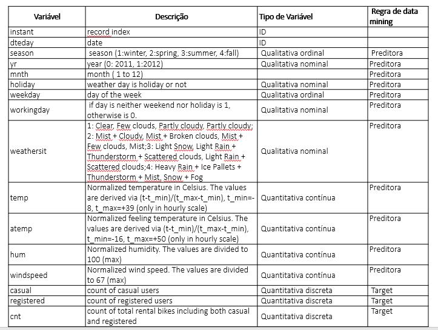

Figura 1.

### Mudar as variaveis quantitativas em qualitativas

### Analise descritiva

Conhecer as variaveis

```
##     instant          dteday           season  yr           mnth     holiday
##  Min.   :  1.0   Min.   :2011-01-01   1:181   0:365   1      : 62   0:710
##  1st Qu.:183.5   1st Qu.:2011-07-02   2:184   1:366   3      : 62   1: 21
##  Median :366.0   Median :2012-01-01   3:188           5      : 62
##  Mean   :366.0   Mean   :2012-01-01   4:178           7      : 62
##  3rd Qu.:548.5   3rd Qu.:2012-07-01                   8      : 62
##  Max.   :731.0   Max.   :2012-12-31                   10     : 62
##                                                       (Other):359
##  weekday workingday weathersit      temp             atemp
##  0:105   0:231      1:463      Min.   :0.05913   Min.   :0.07907
##  1:105   1:500      2:247      1st Qu.:0.33708   1st Qu.:0.33784
##  2:104              3: 21      Median :0.49833   Median :0.48673
##  3:104                         Mean   :0.49538   Mean   :0.47435
##  4:104                         3rd Qu.:0.65542   3rd Qu.:0.60860
##  5:104                         Max.   :0.86167   Max.   :0.84090
##  6:105
##       hum           windspeed           casual         registered
##  Min.   :0.0000   Min.   :0.02239   Min.   :   2.0   Min.   :  20
##  1st Qu.:0.5200   1st Qu.:0.13495   1st Qu.: 315.5   1st Qu.:2497
##  Median :0.6267   Median :0.18097   Median : 713.0   Median :3662
##  Mean   :0.6279   Mean   :0.19049   Mean   : 848.2   Mean   :3656
##  3rd Qu.:0.7302   3rd Qu.:0.23321   3rd Qu.:1096.0   3rd Qu.:4776
##  Max.   :0.9725   Max.   :0.50746   Max.   :3410.0   Max.   :6946
##
##       cnt
##  Min.   :  22
##  1st Qu.:3152
##  Median :4548
##  Mean   :4504
##  3rd Qu.:5956
##  Max.   :8714
##
```

### Grafico univariado

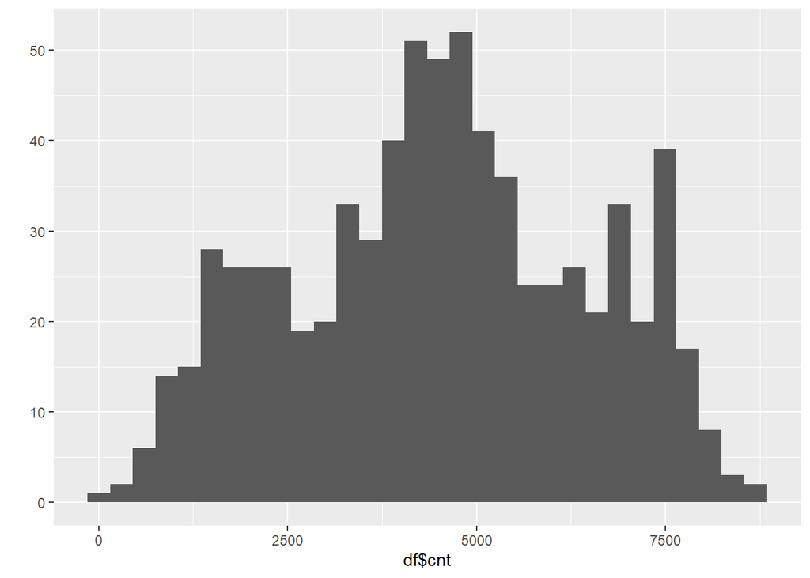

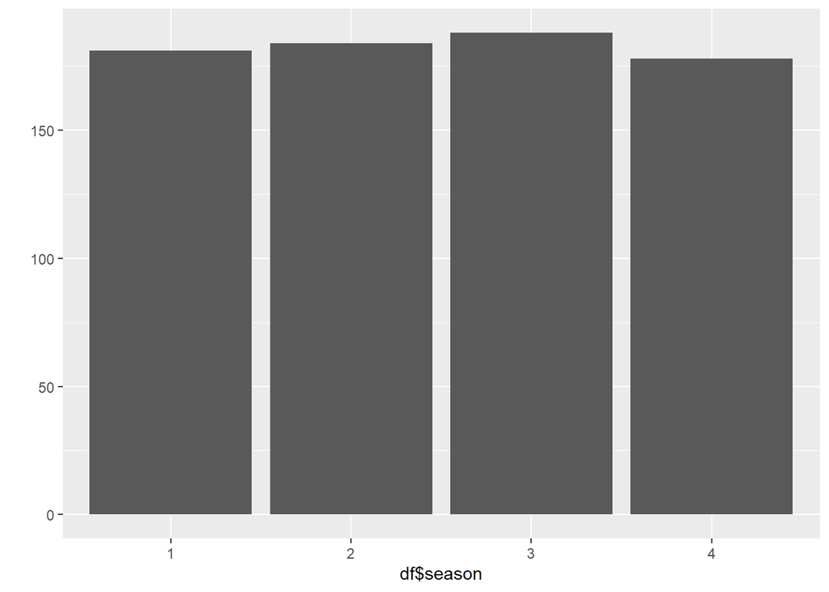

### Gráfico bivariado

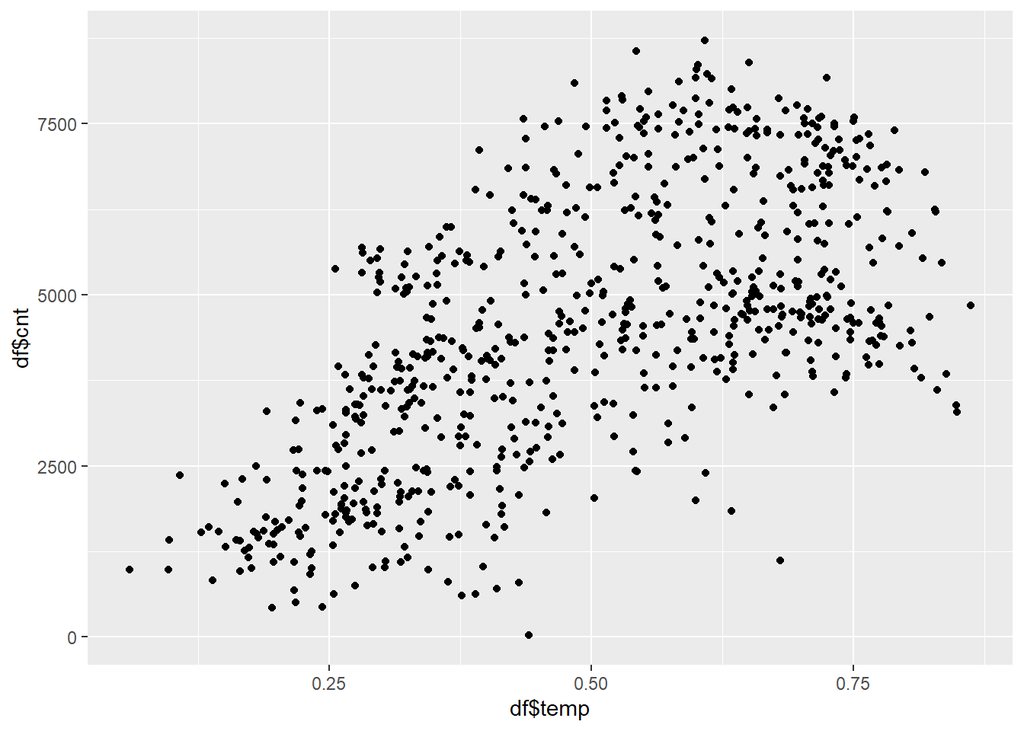

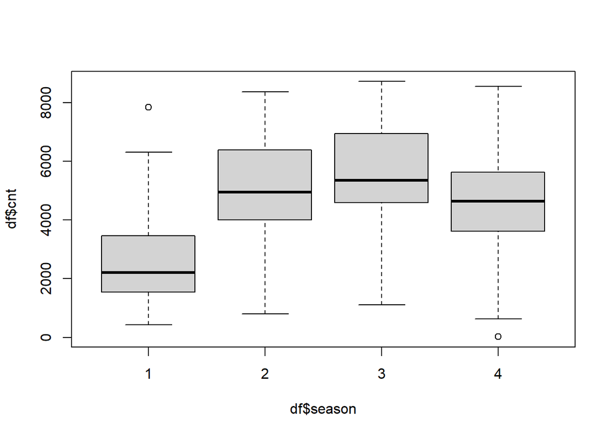

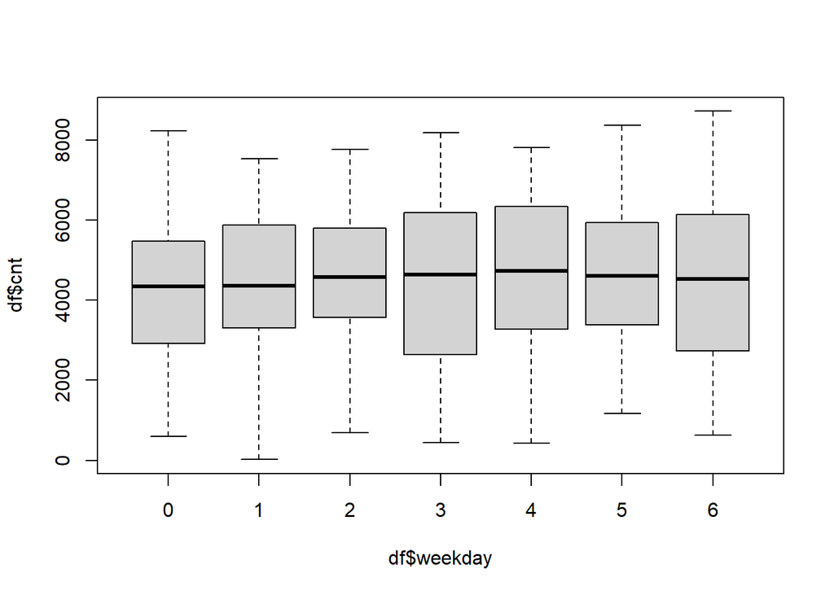

[output not shown]

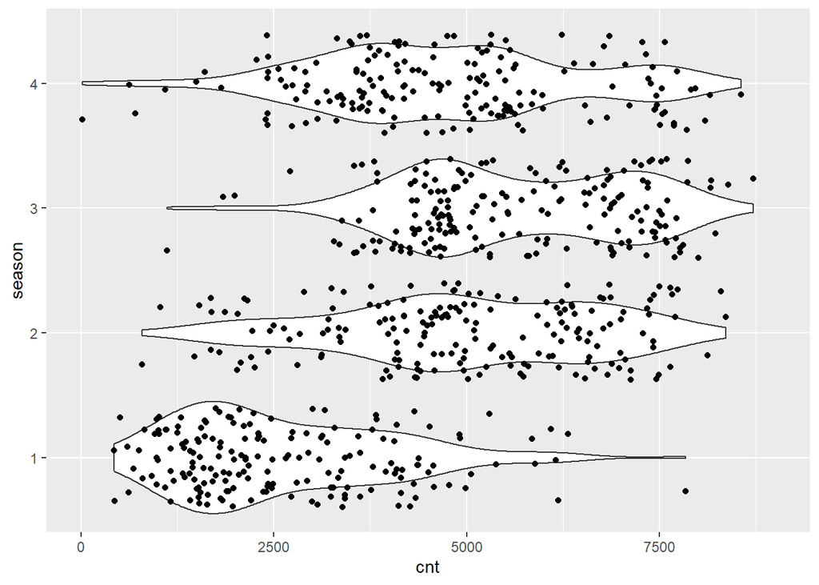

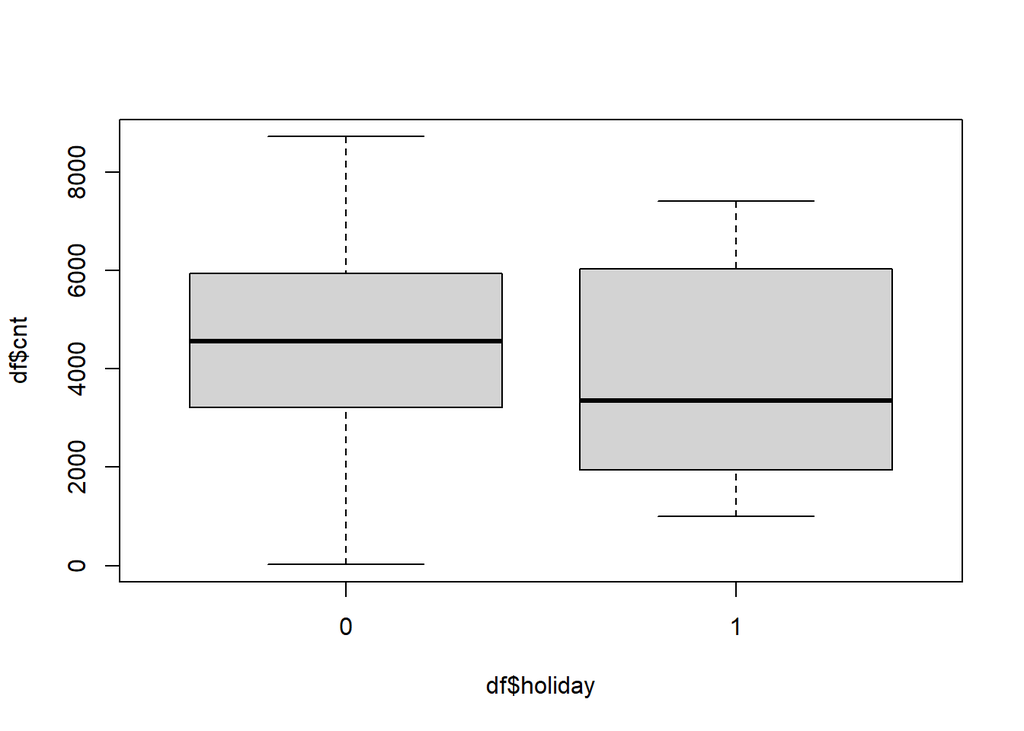

### Grafico de dispersão entre duas variaveis quantitativas e terceira variável qualitativa

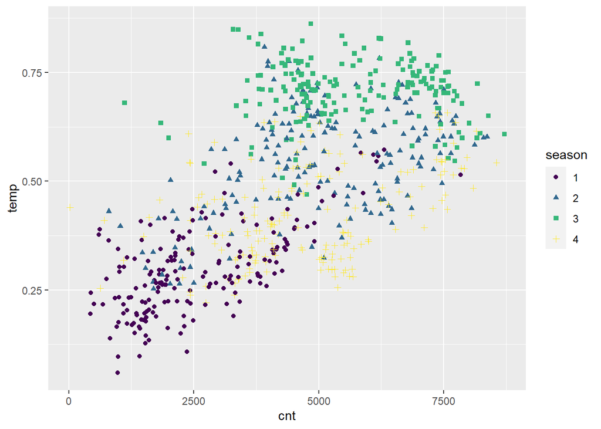

### Gráfico com três variáveis

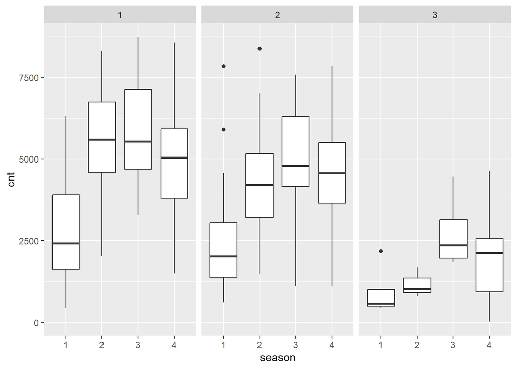

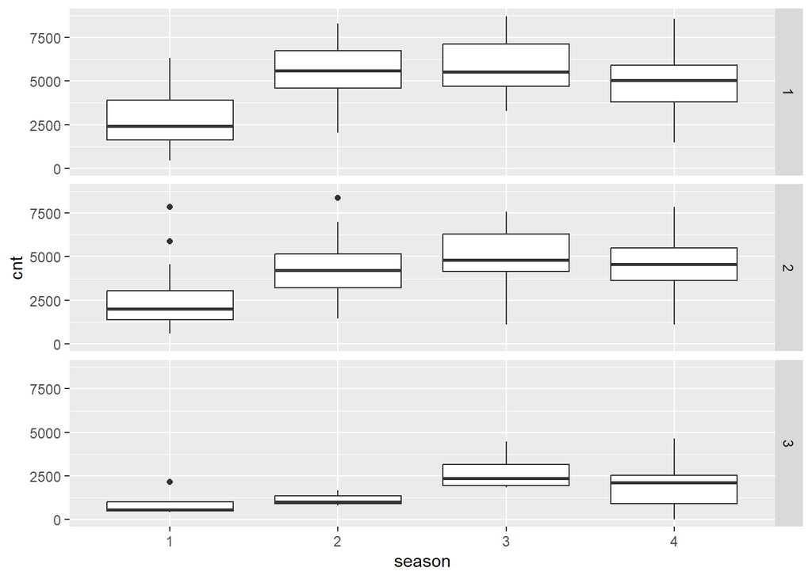

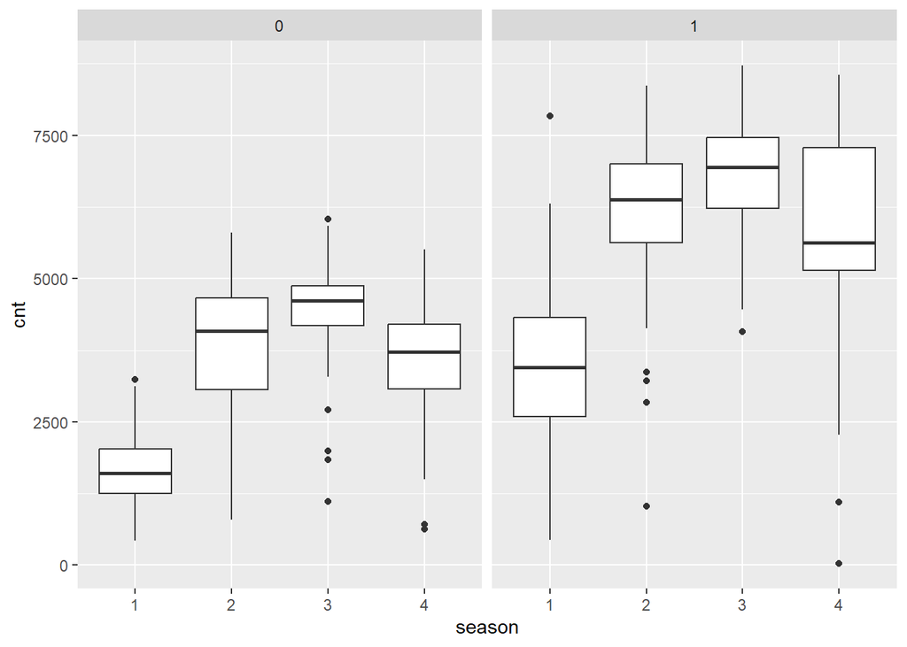

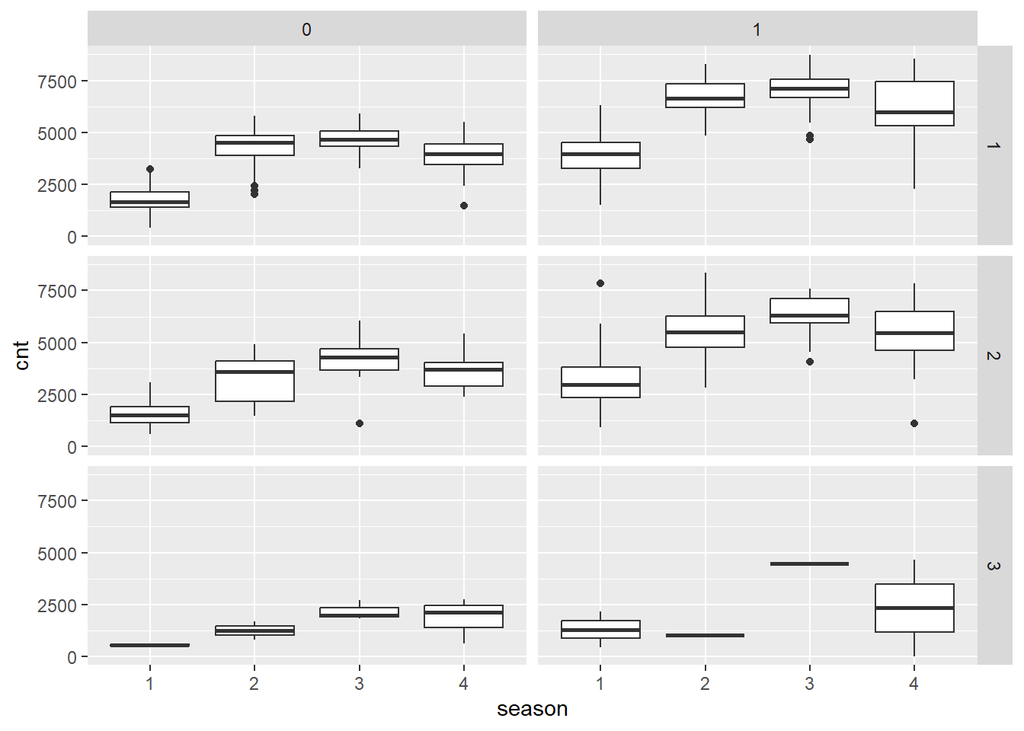

### Análise de correlacao de Pearson

```
##                 temp      atemp        hum  windspeed        cnt
## temp       1.0000000  0.9917016  0.1269629 -0.1579441  0.6274940
## atemp      0.9917016  1.0000000  0.1399881 -0.1836430  0.6310657
## hum        0.1269629  0.1399881  1.0000000 -0.2484891 -0.1006586
## windspeed -0.1579441 -0.1836430 -0.2484891  1.0000000 -0.2345450
## cnt        0.6274940  0.6310657 -0.1006586 -0.2345450  1.0000000
```

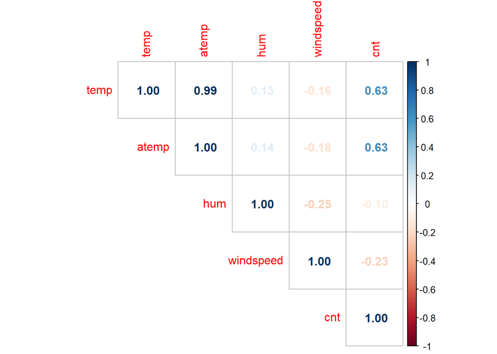

```
##            temp atemp   hum windspeed   cnt
## temp       1.00  0.99  0.13     -0.16  0.63
## atemp      0.99  1.00  0.14     -0.18  0.63
## hum        0.13  0.14  1.00     -0.25 -0.10
## windspeed -0.16 -0.18 -0.25      1.00 -0.23
## cnt        0.63  0.63 -0.10     -0.23  1.00
##
## n= 731
##
##
## P
##           temp   atemp  hum    windspeed cnt
## temp             0.0000 0.0006 0.0000    0.0000
## atemp     0.0000        0.0001 0.0000    0.0000
## hum       0.0006 0.0001        0.0000    0.0065
## windspeed 0.0000 0.0000 0.0000           0.0000
## cnt       0.0000 0.0000 0.0065 0.0000
```

```
##                 temp      atemp        hum  windspeed        cnt
## temp       1.0000000  0.9917016  0.1269629 -0.1579441  0.6274940
## atemp      0.9917016  1.0000000  0.1399881 -0.1836430  0.6310657
## hum        0.1269629  0.1399881  1.0000000 -0.2484891 -0.1006586
## windspeed -0.1579441 -0.1836430 -0.2484891  1.0000000 -0.2345450
## cnt        0.6274940  0.6310657 -0.1006586 -0.2345450  1.0000000
```

```
##                    temp           atemp                  hum
## temp                 NA 0.0000000000000 0.000580088770536280
## atemp     0.00000000000              NA 0.000146402380069688
## hum       0.00058008877 0.0001464023801                   NA
## windspeed 0.00001786857 0.0000005755774 0.000000000009487966
## cnt       0.00000000000 0.0000000000000 0.006454143325438810
##                      windspeed                cnt
## temp      0.000017868574360591 0.0000000000000000
## atemp     0.000000575577391970 0.0000000000000000
## hum       0.000000000009487966 0.0064541433254388
## windspeed                   NA 0.0000000001359959
## cnt       0.000000000135995881                 NA
```

```
##           temp atemp hum windspeed cnt
## temp       731   731 731       731 731
## atemp      731   731 731       731 731
## hum        731   731 731       731 731
## windspeed  731   731 731       731 731
## cnt        731   731 731       731 731
```

[output not shown]

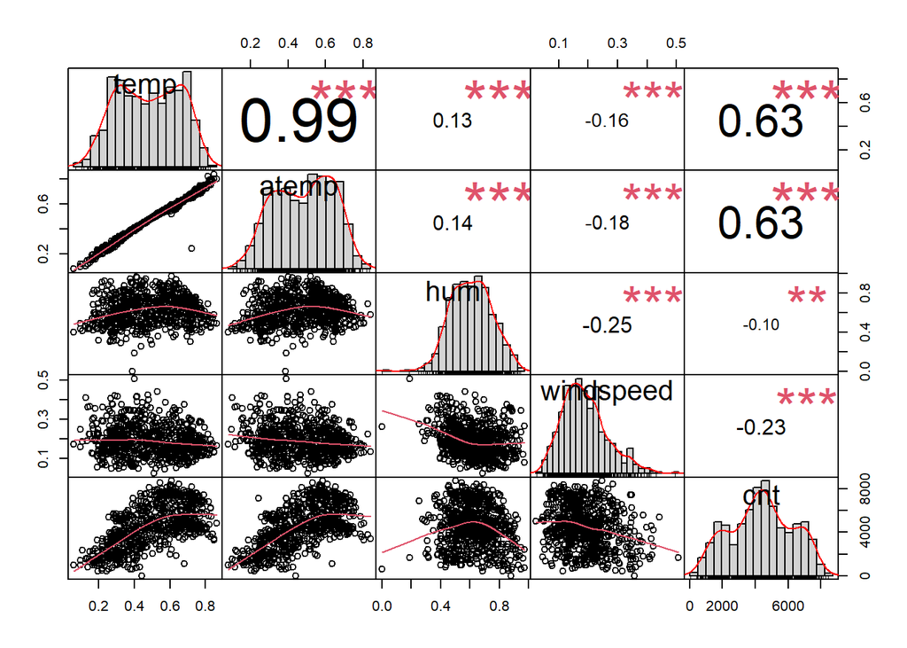

| ## Analise de uma variavel quantitativa versus variavel qualitativa |
| --- |

Analise da variavel cnt vs season, weekday, weathersit, workingday, holiday, month e yr

Primeiro passo: transformar a variavel quantitativa (cnt) em uma qualitativa (faixa de cnt)

Criterio: quartis

```
##    Min. 1st Qu.  Median    Mean 3rd Qu.    Max.
##      22    3152    4548    4504    5956    8714
```

minimo = 22 quartil1 = 3152 quartil2 = 4548 quartil3 = 5956 maximo 8714

ntile() é uma função do dplyr para criar categorias usando os quartis.

```
## Frequencies
## df1$fxcnt_cat
## Type: Ordered Factor
##
##                       Freq   % Valid   % Valid Cum.   % Total   % Total Cum.
## ------------------- ------ --------- -------------- --------- --------------
##        [ 22 a 3152]    183     25.03          25.03     25.03          25.03
##       (3152 a 4548]    183     25.03          50.07     25.03          50.07
##       (4548 a 5956]    183     25.03          75.10     25.03          75.10
##       (5956 a 8714]    182     24.90         100.00     24.90         100.00
##                <NA>      0                               0.00         100.00
##               Total    731    100.00         100.00    100.00         100.00
```

| ## Teste Qui-Quadrado |
| --- |

Análise bivariada cnt vs season

Interpretação da tabela 1: Número absoluto

No total temos 731 dias. Row Total -> mostra a distribuição dos dias segundo a demanda (cnt) de bikes: - 183 dias foram alugadas de 22 a 3152 bikes; - 183 dias foram alugadas de 3152 a 4548 bikes; - 183 dias foram alugadas de 4548 a 5956 bikes; - 182 dias foram alugadas de 5956 a 8714 bikes.

Na primeira linha da faixa de demanda entre 22 e 3152 bikes temos: - 122 dias de inverno; - 28 dias de primavera; - 4 dias de verão; - 29 dias de outono.

Column Total >- mostra a distribuição dos dias segundo a estação do ano (season) - 181 dias de inverno; - 184 dias de primavera; - 188 dias de verão; - 178 dias de outno.

```
##
##
##    Cell Contents
## |-------------------------|
## |                       N |
## |-------------------------|
##
##
## Total Observations in Table:  731
##
##
##               | df1$season_label
## df1$fxcnt_cat |   Inverno | Primavera |     Verao |    Outono | Row Total |
## --------------|-----------|-----------|-----------|-----------|-----------|
##  [ 22 a 3152] |       122 |        28 |         4 |        29 |       183 |
## --------------|-----------|-----------|-----------|-----------|-----------|
## (3152 a 4548] |        43 |        43 |        41 |        56 |       183 |
## --------------|-----------|-----------|-----------|-----------|-----------|
## (4548 a 5956] |        11 |        51 |        65 |        56 |       183 |
## --------------|-----------|-----------|-----------|-----------|-----------|
## (5956 a 8714] |         5 |        62 |        78 |        37 |       182 |
## --------------|-----------|-----------|-----------|-----------|-----------|
##  Column Total |       181 |       184 |       188 |       178 |       731 |
## --------------|-----------|-----------|-----------|-----------|-----------|
##
##
```

Interpretação da tabela 2: Número absoluto e proporção na linha

No total temos 731 dias.

Row Total >- mostra a distribuição dos dias segundo a demanda (cnt) - 183 dias foram alugadas de 22 a 3152 bikes; - 183 dias foram alugadas de 3152 a 4548 bikes; - 183 dias foram alugadas de 4548 a 5956 bikes; - 182 dias foram alugadas de 5956 a 8714 bikes.

Column Total -> mostra a distribuição dos dias segundo a estação do ano (season): - 181 (0.248) dias de inverno; - 184 (0.252) dias de primavera; - 188 (0.257) dias de verão; - 178 (0.244) dias de outono.

```
##
##
##    Cell Contents
## |-------------------------|
## |                       N |
## |           N / Row Total |
## |-------------------------|
##
##
## Total Observations in Table:  731
##
##
##               | df1$season_label
## df1$fxcnt_cat |   Inverno | Primavera |     Verao |    Outono | Row Total |
## --------------|-----------|-----------|-----------|-----------|-----------|
##  [ 22 a 3152] |       122 |        28 |         4 |        29 |       183 |
##               |     0.667 |     0.153 |     0.022 |     0.158 |     0.250 |
## --------------|-----------|-----------|-----------|-----------|-----------|
## (3152 a 4548] |        43 |        43 |        41 |        56 |       183 |
##               |     0.235 |     0.235 |     0.224 |     0.306 |     0.250 |
## --------------|-----------|-----------|-----------|-----------|-----------|
## (4548 a 5956] |        11 |        51 |        65 |        56 |       183 |
##               |     0.060 |     0.279 |     0.355 |     0.306 |     0.250 |
## --------------|-----------|-----------|-----------|-----------|-----------|
## (5956 a 8714] |         5 |        62 |        78 |        37 |       182 |
##               |     0.027 |     0.341 |     0.429 |     0.203 |     0.249 |
## --------------|-----------|-----------|-----------|-----------|-----------|
##  Column Total |       181 |       184 |       188 |       178 |       731 |
## --------------|-----------|-----------|-----------|-----------|-----------|
##
##
```

Interpretação do gráfico 1:

A última coluna do gráfico mostra a distribuição dos dias segundo a demanda (cnt) de bikes. Essa proporção pode ser interpretada como uma média.

Na comparação entre cada coluna do gráfico com o total, nota-se que a distribuição é diferente. Ou seja, a demanda de bikes depende da estação do ano.

Na comparação entre a primeira faixa de cnt (22 a 3152) e a última (total), nota-se que a distribuição dos dias é diferente do total. Existe uma concentração dos dias no inverso quando comparada ao total dos dias.

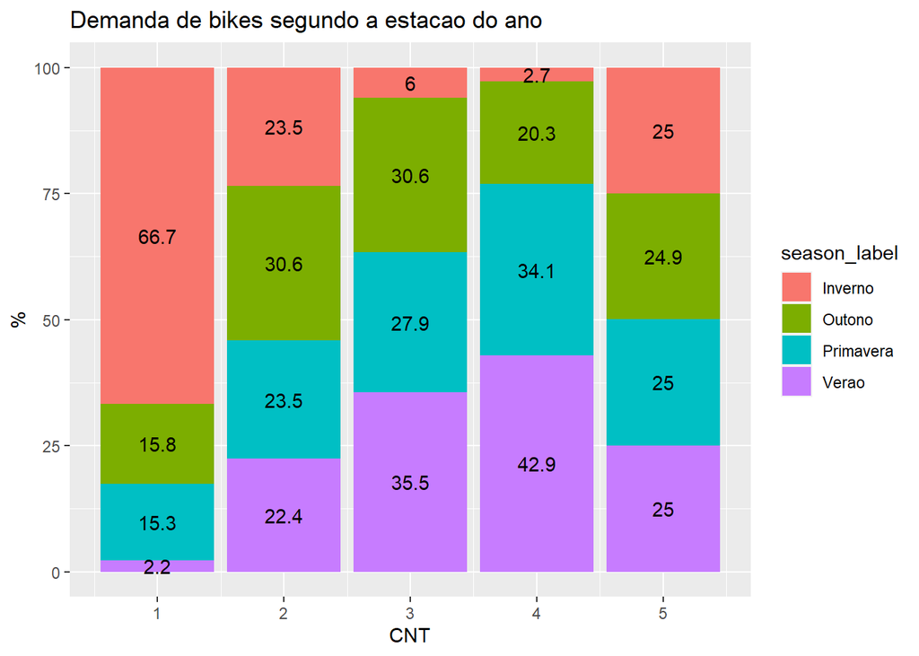

Interpretação da Tabela 3 (4 linhas e 4 colunas): Número observado e o número esperado

Tabela 4 x 4 = 16 células

Cálculo do número esperado

```
##
##
##    Cell Contents
## |-------------------------|
## |                       N |
## |              Expected N |
## |-------------------------|
##
##
## Total Observations in Table:  731
##
##
##               | df1$season_label
## df1$fxcnt_cat |   Inverno | Primavera |     Verao |    Outono | Row Total |
## --------------|-----------|-----------|-----------|-----------|-----------|
##  [ 22 a 3152] |       122 |        28 |         4 |        29 |       183 |
##               |    45.312 |    46.063 |    47.064 |    44.561 |           |
## --------------|-----------|-----------|-----------|-----------|-----------|
## (3152 a 4548] |        43 |        43 |        41 |        56 |       183 |
##               |    45.312 |    46.063 |    47.064 |    44.561 |           |
## --------------|-----------|-----------|-----------|-----------|-----------|
## (4548 a 5956] |        11 |        51 |        65 |        56 |       183 |
##               |    45.312 |    46.063 |    47.064 |    44.561 |           |
## --------------|-----------|-----------|-----------|-----------|-----------|
## (5956 a 8714] |         5 |        62 |        78 |        37 |       182 |
##               |    45.064 |    45.811 |    46.807 |    44.317 |           |
## --------------|-----------|-----------|-----------|-----------|-----------|
##  Column Total |       181 |       184 |       188 |       178 |       731 |
## --------------|-----------|-----------|-----------|-----------|-----------|
##
##
## Statistics for All Table Factors
##
##
## Pearson's Chi-squared test
## ------------------------------------------------------------
## Chi^2 =  285.37     d.f. =  9     p =  0.00000000000000000000000000000000000000000000000000000003296655
##
##
##
```

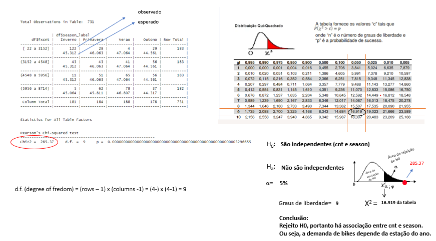

Figura 2.

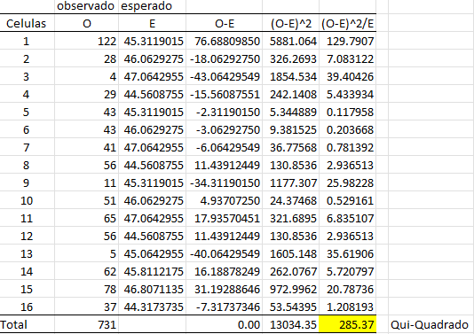

Figura 3

Análise de associação entre cnt e weekday

Conclusão: p_valor > 0,05. Logo, não existe associação. Ou seja, a demanda de bikes não depende do dia da semana.

```
##
##
##    Cell Contents
## |-------------------------|
## |                       N |
## |           N / Row Total |
## |           N / Col Total |
## |-------------------------|
##
##
## Total Observations in Table:  731
##
##
##               | df1$weekday
## df1$fxcnt_cat |         0 |         1 |         2 |         3 |         4 |         5 |         6 | Row Total |
## --------------|-----------|-----------|-----------|-----------|-----------|-----------|-----------|-----------|
##  [ 22 a 3152] |        29 |        25 |        24 |        29 |        25 |        20 |        31 |       183 |
##               |     0.158 |     0.137 |     0.131 |     0.158 |     0.137 |     0.109 |     0.169 |     0.250 |
##               |     0.276 |     0.238 |     0.231 |     0.279 |     0.240 |     0.192 |     0.295 |           |
## --------------|-----------|-----------|-----------|-----------|-----------|-----------|-----------|-----------|
## (3152 a 4548] |        27 |        34 |        27 |        21 |        23 |        29 |        22 |       183 |
##               |     0.148 |     0.186 |     0.148 |     0.115 |     0.126 |     0.158 |     0.120 |     0.250 |
##               |     0.257 |     0.324 |     0.260 |     0.202 |     0.221 |     0.279 |     0.210 |           |
## --------------|-----------|-----------|-----------|-----------|-----------|-----------|-----------|-----------|
## (4548 a 5956] |        27 |        21 |        30 |        27 |        25 |        29 |        24 |       183 |
##               |     0.148 |     0.115 |     0.164 |     0.148 |     0.137 |     0.158 |     0.131 |     0.250 |
##               |     0.257 |     0.200 |     0.288 |     0.260 |     0.240 |     0.279 |     0.229 |           |
## --------------|-----------|-----------|-----------|-----------|-----------|-----------|-----------|-----------|
## (5956 a 8714] |        22 |        25 |        23 |        27 |        31 |        26 |        28 |       182 |
##               |     0.121 |     0.137 |     0.126 |     0.148 |     0.170 |     0.143 |     0.154 |     0.249 |
##               |     0.210 |     0.238 |     0.221 |     0.260 |     0.298 |     0.250 |     0.267 |           |
## --------------|-----------|-----------|-----------|-----------|-----------|-----------|-----------|-----------|
##  Column Total |       105 |       105 |       104 |       104 |       104 |       104 |       105 |       731 |
##               |     0.144 |     0.144 |     0.142 |     0.142 |     0.142 |     0.142 |     0.144 |           |
## --------------|-----------|-----------|-----------|-----------|-----------|-----------|-----------|-----------|
##
##
## Statistics for All Table Factors
##
##
## Pearson's Chi-squared test
## ------------------------------------------------------------
## Chi^2 =  12.3245     d.f. =  18     p =  0.8300395
##
##
##
```

[figure not shown]

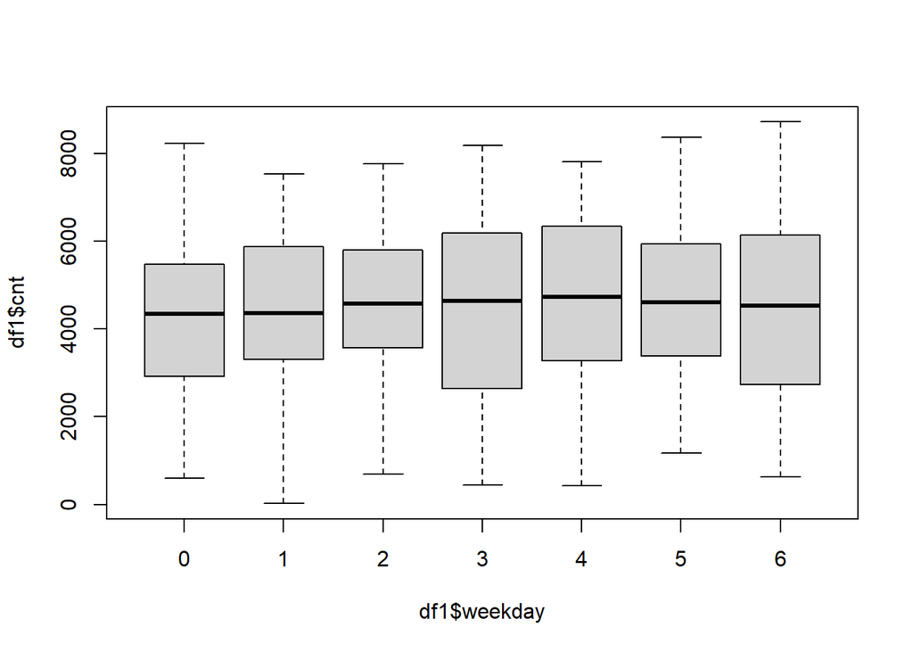

### Criar as variáveis dummies

```
##  [1] "instant"     "dteday"      "season"      "yr"          "mnth"
##  [6] "holiday"     "weekday"     "workingday"  "weathersit"  "temp"
## [11] "atemp"       "hum"         "windspeed"   "casual"      "registered"
## [16] "cnt"         "season2"     "season3"     "season4"     "weekday1"
## [21] "weekday2"    "weekday3"    "weekday4"    "weekday5"    "weekday6"
## [26] "weathersit2" "weathersit3" "mnth2"       "mnth3"       "mnth4"
## [31] "mnth5"       "mnth6"       "mnth7"       "mnth8"       "mnth9"
## [36] "mnth10"      "mnth11"      "mnth12"
```

### Modelo de Regressão Linear Múltipla

```
##  [1] "yr"          "holiday"     "workingday"  "temp"        "atemp"
##  [6] "hum"         "windspeed"   "cnt"         "season2"     "season3"
## [11] "season4"     "weekday1"    "weekday2"    "weekday3"    "weekday4"
## [16] "weekday5"    "weekday6"    "weathersit2" "weathersit3" "mnth2"
## [21] "mnth3"       "mnth4"       "mnth5"       "mnth6"       "mnth7"
## [26] "mnth8"       "mnth9"       "mnth10"      "mnth11"      "mnth12"
```

### Dividir a amostra em treino e validação

### Comparar a variável resposta nas duas amostras

```
##    Min. 1st Qu.  Median    Mean 3rd Qu.    Max.
##      22    3140    4548    4502    5989    8714
```

```
##    Min. 1st Qu.  Median    Mean 3rd Qu.    Max.
##     441    3196    4537    4509    5854    8555
```

### Rodar o modelo

```
##
## Call:
## lm(formula = cnt ~ temp, data = TrainSet)
##
## Residuals:
##     Min      1Q  Median      3Q     Max
## -4605.2 -1169.7  -155.6  1053.4  3675.3
##
## Coefficients:
##             Estimate Std. Error t value             Pr(>|t|)
## (Intercept)   1187.0      196.2   6.051        0.00000000279 ***
## temp          6666.4      370.3  18.004 < 0.0000000000000002 ***
## ---
## Signif. codes:  0 '***' 0.001 '**' 0.01 '*' 0.05 '.' 0.1 ' ' 1
##
## Residual standard error: 1529 on 509 degrees of freedom
## Multiple R-squared:  0.3891, Adjusted R-squared:  0.3879
## F-statistic: 324.1 on 1 and 509 DF,  p-value: < 0.00000000000000022
```

```
##
## Call:
## lm(formula = cnt ~ temp + atemp + temp * atemp, data = TrainSet)
##
## Residuals:
##     Min      1Q  Median      3Q     Max
## -4565.7 -1082.3  -131.2  1138.6  3243.5
##
## Coefficients:
##             Estimate Std. Error t value       Pr(>|t|)
## (Intercept)  -1683.9      479.9  -3.509        0.00049 ***
## temp         11600.7     2780.2   4.173 0.000035435066 ***
## atemp         8747.9     2907.9   3.008        0.00276 **
## temp:atemp  -14076.7     2200.9  -6.396 0.000000000363 ***
## ---
## Signif. codes:  0 '***' 0.001 '**' 0.01 '*' 0.05 '.' 0.1 ' ' 1
##
## Residual standard error: 1472 on 507 degrees of freedom
## Multiple R-squared:  0.4362, Adjusted R-squared:  0.4329
## F-statistic: 130.8 on 3 and 507 DF,  p-value: < 0.00000000000000022
```

```
##
## Call:
## lm(formula = cnt ~ temp + hum, data = TrainSet)
##
## Residuals:
##     Min      1Q  Median      3Q     Max
## -4611.4 -1147.1  -141.1  1021.7  3559.5
##
## Coefficients:
##             Estimate Std. Error t value             Pr(>|t|)
## (Intercept)   2528.2      323.8   7.807   0.0000000000000337 ***
## temp          6955.1      365.7  19.017 < 0.0000000000000002 ***
## hum          -2382.8      464.0  -5.135   0.0000004027157641 ***
## ---
## Signif. codes:  0 '***' 0.001 '**' 0.01 '*' 0.05 '.' 0.1 ' ' 1
##
## Residual standard error: 1492 on 508 degrees of freedom
## Multiple R-squared:  0.4192, Adjusted R-squared:  0.4169
## F-statistic: 183.3 on 2 and 508 DF,  p-value: < 0.00000000000000022
```

```
##
## Call:
## lm(formula = cnt ~ ., data = TrainSet)
##
## Residuals:
##     Min      1Q  Median      3Q     Max
## -3732.1  -349.6    88.3   446.5  2799.6
##
## Coefficients: (1 not defined because of singularities)
##               Estimate Std. Error t value             Pr(>|t|)
## (Intercept)   1545.612    288.919   5.350    0.000000136453783 ***
## yr1           2034.167     73.643  27.622 < 0.0000000000000002 ***
## holiday1      -464.586    269.921  -1.721              0.08586 .
## workingday1    388.227    135.296   2.869              0.00429 **
## temp          3774.324   1570.166   2.404              0.01660 *
## atemp         1246.523   1624.106   0.768              0.44315
## hum          -1710.369    361.198  -4.735    0.000002881102774 ***
## windspeed    -3056.243    512.801  -5.960    0.000000004878624 ***
## season21       882.026    204.289   4.318    0.000019161181091 ***
## season31       722.818    258.410   2.797              0.00536 **
## season41      1393.718    234.280   5.949    0.000000005192683 ***
## weekday11     -143.601    139.075  -1.033              0.30233
## weekday21     -153.298    136.419  -1.124              0.26169
## weekday31      -45.141    138.295  -0.326              0.74425
## weekday41      -23.235    132.535  -0.175              0.86091
## weekday51           NA         NA      NA                   NA
## weekday61      440.071    133.004   3.309              0.00101 **
## weathersit21  -414.793     96.594  -4.294    0.000021210655962 ***
## weathersit31 -1918.036    255.827  -7.497    0.000000000000315 ***
## mnth21          61.456    181.722   0.338              0.73537
## mnth31         492.212    199.706   2.465              0.01406 *
## mnth41         378.192    302.587   1.250              0.21196
## mnth51         655.860    323.972   2.024              0.04348 *
## mnth61         357.829    340.183   1.052              0.29339
## mnth71         -48.067    388.153  -0.124              0.90150
## mnth81         352.198    372.905   0.944              0.34540
## mnth91         980.124    327.794   2.990              0.00293 **
## mnth101        510.095    310.360   1.644              0.10092
## mnth111        -23.414    296.663  -0.079              0.93712
## mnth121         -4.806    239.315  -0.020              0.98399
## ---
## Signif. codes:  0 '***' 0.001 '**' 0.01 '*' 0.05 '.' 0.1 ' ' 1
##
## Residual standard error: 804.1 on 482 degrees of freedom
## Multiple R-squared:   0.84,  Adjusted R-squared:  0.8307
## F-statistic: 90.37 on 28 and 482 DF,  p-value: < 0.00000000000000022
```

```
## Start:  AIC=6864.98
## cnt ~ yr + holiday + workingday + temp + atemp + hum + windspeed +
##     season2 + season3 + season4 + weekday1 + weekday2 + weekday3 +
##     weekday4 + weekday5 + weekday6 + weathersit2 + weathersit3 +
##     mnth2 + mnth3 + mnth4 + mnth5 + mnth6 + mnth7 + mnth8 + mnth9 +
##     mnth10 + mnth11 + mnth12
##
##
## Step:  AIC=6864.98
## cnt ~ yr + holiday + workingday + temp + atemp + hum + windspeed +
##     season2 + season3 + season4 + weekday1 + weekday2 + weekday3 +
##     weekday4 + weekday6 + weathersit2 + weathersit3 + mnth2 +
##     mnth3 + mnth4 + mnth5 + mnth6 + mnth7 + mnth8 + mnth9 + mnth10 +
##     mnth11 + mnth12
##
##               Df Sum of Sq       RSS    AIC
## - mnth12       1       261 311615107 6863.0
## - mnth11       1      4027 311618874 6863.0
## - mnth7        1      9914 311624761 6863.0
## - weekday4     1     19870 311634717 6863.0
## - weekday3     1     68882 311683728 6863.1
## - mnth2        1     73940 311688787 6863.1
## - atemp        1    380840 311995686 6863.6
## - mnth8        1    576698 312191544 6863.9
## - weekday1     1    689273 312304119 6864.1
## - mnth6        1    715312 312330159 6864.2
## - weekday2     1    816377 312431223 6864.3
## - mnth4        1   1009940 312624786 6864.6
## <none>                     311614846 6865.0
## - mnth10       1   1746392 313361238 6865.8
## - holiday      1   1915262 313530108 6866.1
## - mnth5        1   2649596 314264443 6867.3
## - temp         1   3735582 315350429 6869.1
## - mnth3        1   3927306 315542152 6869.4
## - season3      1   5058386 316673232 6871.2
## - workingday   1   5323147 316937993 6871.6
## - mnth9        1   5780050 317394897 6872.4
## - weekday6     1   7077647 318692494 6874.5
## - weathersit2  1  11921576 323536422 6882.2
## - season2      1  12051636 323666483 6882.4
```

[output cut: 328 more lines]

```
## - mnth5        1   5650937 319118131 6857.1
## - workingday   1   6147544 319614737 6857.9
## - mnth10       1   6987099 320454293 6859.3
## - weekday6     1   7207850 320675043 6859.6
## - mnth3        1   7318964 320786158 6859.8
## - season3      1   7450096 320917290 6860.0
## - weathersit2  1  12006336 325473530 6867.2
## - season2      1  13854614 327321808 6870.1
## - hum          1  15636377 329103571 6872.9
## - windspeed    1  25167620 338634814 6887.5
## - mnth9        1  27091228 340558421 6890.4
## - weathersit3  1  36707459 350174652 6904.6
## - season4      1  70965662 384432855 6952.3
## - temp         1  97793831 411261024 6986.8
## - yr           1 502090312 815557505 7336.6
```

```
##
## Call:
## lm(formula = cnt ~ yr + holiday + workingday + temp + hum + windspeed +
##     season2 + season3 + season4 + weekday6 + weathersit2 + weathersit3 +
##     mnth3 + mnth4 + mnth5 + mnth6 + mnth8 + mnth9 + mnth10, data = TrainSet)
##
## Residuals:
##     Min      1Q  Median      3Q     Max
## -3835.7  -347.3   113.6   467.5  2794.5
##
## Coefficients:
##              Estimate Std. Error t value             Pr(>|t|)
## (Intercept)   1628.38     273.08   5.963    0.000000004738424 ***
## yr1           2035.87      72.60  28.044 < 0.0000000000000002 ***
## holiday1      -598.48     235.50  -2.541             0.011351 *
## workingday1    321.25     103.52   3.103             0.002025 **
## temp          4870.00     393.49  12.377 < 0.0000000000000002 ***
## hum          -1725.52     348.66  -4.949    0.000001027142937 ***
## windspeed    -3122.91     497.39  -6.279    0.000000000752174 ***
## season21       853.40     183.19   4.658    0.000004108019924 ***
## season31       671.53     196.58   3.416             0.000688 ***
## season41      1362.38     129.22  10.543 < 0.0000000000000002 ***
## weekday61      442.94     131.83   3.360             0.000840 ***
## weathersit21  -410.65      94.69  -4.337    0.000017568743204 ***
## weathersit31 -1920.58     253.29  -7.583    0.000000000000171 ***
## mnth31         490.89     144.98   3.386             0.000766 ***
## mnth41         397.57     226.18   1.758             0.079417 .
## mnth51         678.69     228.12   2.975             0.003073 **
## mnth61         372.76     189.93   1.963             0.050259 .
## mnth81         367.80     163.94   2.243             0.025311 *
## mnth91        1006.52     154.51   6.514    0.000000000181267 ***
## mnth101        534.47     161.56   3.308             0.001008 **
## ---
## Signif. codes:  0 '***' 0.001 '**' 0.01 '*' 0.05 '.' 0.1 ' ' 1
##
## Residual standard error: 799 on 491 degrees of freedom
## Multiple R-squared:  0.839,  Adjusted R-squared:  0.8328
## F-statistic: 134.7 on 19 and 491 DF,  p-value: < 0.00000000000000022
```

```
## [1] 783.2233
```

### Análise dos resíduos do modelo

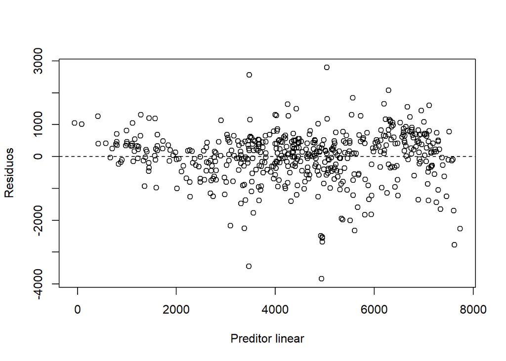

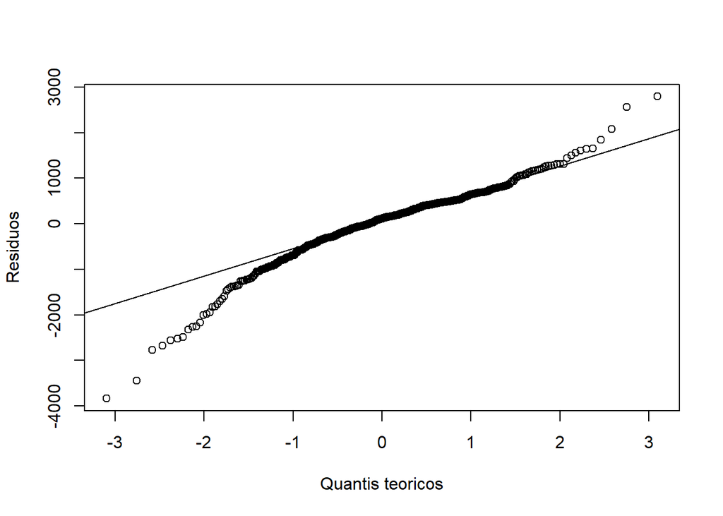

```
##
##  Shapiro-Wilk normality test
##
## data:  residuals(modelo3_stepwise)
## W = 0.94646, p-value = 0.000000000001251
```

### Segunda rodada do modelo

```
##
## Call:
## lm(formula = cnt ~ ., data = TrainSet_1)
##
## Residuals:
##      Min       1Q   Median       3Q      Max
## -1872.76  -360.84    28.37   389.05  1425.90
##
## Coefficients: (1 not defined because of singularities)
##              Estimate Std. Error t value             Pr(>|t|)
## (Intercept)   1250.25     220.99   5.657    0.000000027202383 ***
## yr1           2144.05      56.60  37.879 < 0.0000000000000002 ***
## holiday1      -412.61     214.38  -1.925             0.054891 .
## workingday1    483.12     103.93   4.649    0.000004381973961 ***
## temp          2782.15    1189.17   2.340             0.019737 *
## atemp         1709.80    1228.36   1.392             0.164620
## hum          -1343.94     274.55  -4.895    0.000001367380381 ***
## windspeed    -2339.63     400.73  -5.838    0.000000010032084 ***
## season21       800.15     158.86   5.037    0.000000683676860 ***
## season31       794.87     202.21   3.931    0.000097787755111 ***
## season41      1377.10     184.78   7.453    0.000000000000465 ***
## weekday11     -202.32     106.13  -1.906             0.057239 .
## weekday21     -165.02     104.19  -1.584             0.113904
## weekday31     -179.64     104.27  -1.723             0.085609 .
## weekday41      -77.37     100.75  -0.768             0.442903
## weekday51          NA         NA      NA                   NA
## weekday61      513.91     103.80   4.951    0.000001042561789 ***
## weathersit21  -507.42      72.68  -6.981    0.000000000010417 ***
## weathersit31 -1803.64     195.82  -9.211 < 0.0000000000000002 ***
## mnth21          81.42     135.02   0.603             0.546807
## mnth31         496.08     151.11   3.283             0.001107 **
## mnth41         573.74     233.18   2.461             0.014242 *
## mnth51         963.77     250.23   3.852             0.000134 ***
## mnth61         821.11     265.49   3.093             0.002104 **
## mnth71         248.82     306.21   0.813             0.416887
## mnth81         610.83     293.64   2.080             0.038069 *
## mnth91        1186.02     258.43   4.589    0.000005758773534 ***
## mnth101        860.25     245.74   3.501             0.000510 ***
## mnth111        258.72     232.53   1.113             0.266463
## mnth121        142.88     190.03   0.752             0.452523
## ---
## Signif. codes:  0 '***' 0.001 '**' 0.01 '*' 0.05 '.' 0.1 ' ' 1
##
## Residual standard error: 595.3 on 455 degrees of freedom
## Multiple R-squared:  0.9098, Adjusted R-squared:  0.9043
## F-statistic:   164 on 28 and 455 DF,  p-value: < 0.00000000000000022
```

```
## Start:  AIC=6212.69
## cnt ~ yr + holiday + workingday + temp + atemp + hum + windspeed +
##     season2 + season3 + season4 + weekday1 + weekday2 + weekday3 +
##     weekday4 + weekday5 + weekday6 + weathersit2 + weathersit3 +
##     mnth2 + mnth3 + mnth4 + mnth5 + mnth6 + mnth7 + mnth8 + mnth9 +
##     mnth10 + mnth11 + mnth12
##
##
## Step:  AIC=6212.69
## cnt ~ yr + holiday + workingday + temp + atemp + hum + windspeed +
##     season2 + season3 + season4 + weekday1 + weekday2 + weekday3 +
##     weekday4 + weekday6 + weathersit2 + weathersit3 + mnth2 +
##     mnth3 + mnth4 + mnth5 + mnth6 + mnth7 + mnth8 + mnth9 + mnth10 +
##     mnth11 + mnth12
##
##               Df Sum of Sq       RSS    AIC
## - mnth2        1    128852 161366051 6211.1
## - mnth12       1    200323 161437522 6211.3
## - weekday4     1    208998 161446197 6211.3
## - mnth7        1    233981 161471180 6211.4
## - mnth11       1    438673 161675872 6212.0
## <none>                     161237199 6212.7
## - atemp        1    686588 161923787 6212.7
## - weekday2     1    889050 162126249 6213.4
## - weekday3     1   1051742 162288941 6213.8
## - weekday1     1   1287781 162524980 6214.5
## - holiday      1   1312735 162549934 6214.6
## - mnth8        1   1533390 162770589 6215.3
## - temp         1   1939678 163176877 6216.5
## - mnth4        1   2145489 163382688 6217.1
## - mnth6        1   3389775 164626974 6220.8
## - mnth3        1   3819127 165056326 6222.0
## - mnth10       1   4342785 165579984 6223.6
## - mnth5        1   5257000 166494199 6226.2
## - season3      1   5475749 166712948 6226.9
## - mnth9        1   7463768 168700967 6232.6
## - workingday   1   7658117 168895316 6233.1
## - hum          1   8491056 169728255 6235.5
## - weekday6     1   8686054 169923253 6236.1
## - season2      1   8990170 170227369 6237.0
```

[output cut: 404 more lines]

```
## - mnth3        1   4517465 166866761 6213.3
## - workingday   1   5765758 168115054 6216.9
## - mnth6        1   5910753 168260049 6217.3
## - mnth5        1   7484256 169833552 6221.8
## - weekday6     1   8884192 171233488 6225.8
## - mnth10       1   9062598 171411894 6226.3
## - hum          1   9619254 171968550 6227.9
## - windspeed    1  12032377 174381673 6234.6
## - season3      1  12085043 174434339 6234.8
## - season2      1  12381143 174730439 6235.6
## - weathersit2  1  17319824 179669120 6249.1
## - mnth9        1  23095259 185444555 6264.4
## - weathersit3  1  29649754 191999050 6281.2
## - season4      1  82569358 244918654 6399.0
## - yr           1 513981213 676330509 6890.7
```

```
##
## Call:
## lm(formula = cnt ~ yr + holiday + workingday + temp + hum + windspeed +
##     season2 + season3 + season4 + weekday6 + weathersit2 + weathersit3 +
##     mnth3 + mnth4 + mnth5 + mnth6 + mnth8 + mnth9 + mnth10 +
##     weekday5 + atemp, data = TrainSet_1)
##
## Residuals:
##      Min       1Q   Median       3Q      Max
## -1920.60  -360.38    35.46   396.38  1429.06
##
## Coefficients:
##              Estimate Std. Error t value             Pr(>|t|)
## (Intercept)   1274.52     214.64   5.938   0.0000000056763137 ***
## yr1           2138.41      55.91  38.245 < 0.0000000000000002 ***
## holiday1      -601.06     187.90  -3.199             0.001475 **
## workingday1    328.45      81.09   4.051   0.0000599039425158 ***
## temp          2987.22    1142.53   2.615             0.009226 **
## hum          -1390.11     265.69  -5.232   0.0000002548498618 ***
## windspeed    -2314.00     395.45  -5.852   0.0000000092360321 ***
## season21       848.19     142.90   5.936   0.0000000057488721 ***
## season31       890.45     151.84   5.864   0.0000000085971956 ***
## season41      1512.47      98.67  15.329 < 0.0000000000000002 ***
## weekday61      518.36     103.09   5.028   0.0000007099691536 ***
## weathersit21  -504.35      71.84  -7.020   0.0000000000079370 ***
## weathersit31 -1785.10     194.34  -9.186 < 0.0000000000000002 ***
## mnth31         398.61     111.17   3.585             0.000372 ***
## mnth41         430.24     174.52   2.465             0.014055 *
## mnth51         815.93     176.80   4.615   0.0000051001700575 ***
## mnth61         622.29     151.73   4.101   0.0000485591206195 ***
## mnth81         378.36     127.05   2.978             0.003055 **
## mnth91         969.19     119.55   8.107   0.0000000000000047 ***
## mnth101        637.14     125.46   5.078   0.0000005533036544 ***
## weekday51      157.13      81.86   1.919             0.055541 .
## atemp         1699.25    1219.41   1.393             0.164139
## ---
## Signif. codes:  0 '***' 0.001 '**' 0.01 '*' 0.05 '.' 0.1 ' ' 1
##
## Residual standard error: 592.8 on 462 degrees of freedom
## Multiple R-squared:  0.9092, Adjusted R-squared:  0.9051
## F-statistic: 220.3 on 21 and 462 DF,  p-value: < 0.00000000000000022
```

```
## [1] 579.1653
```

### Análise dos resíduos do segundo modelo

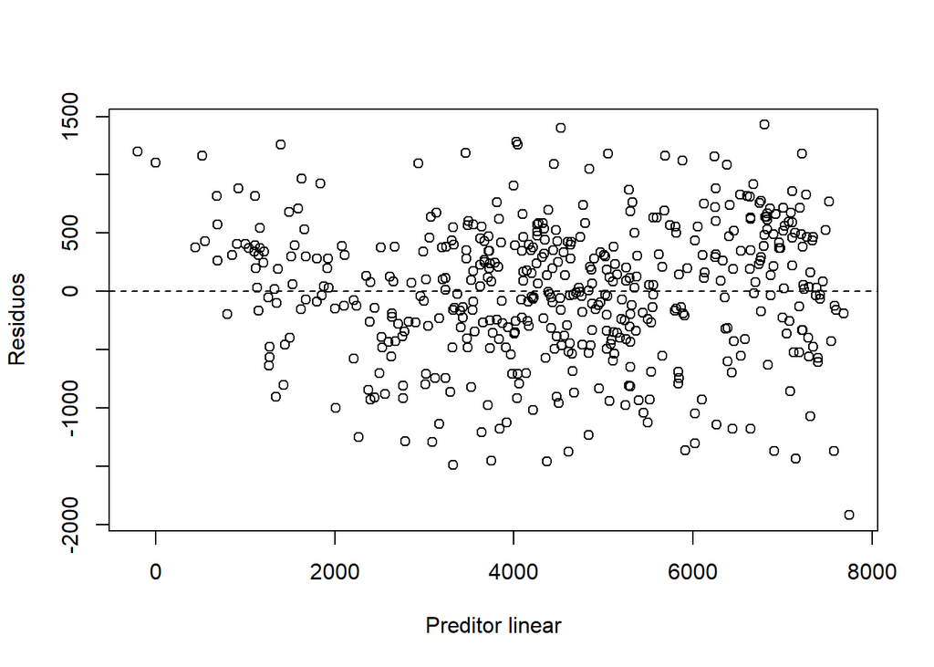

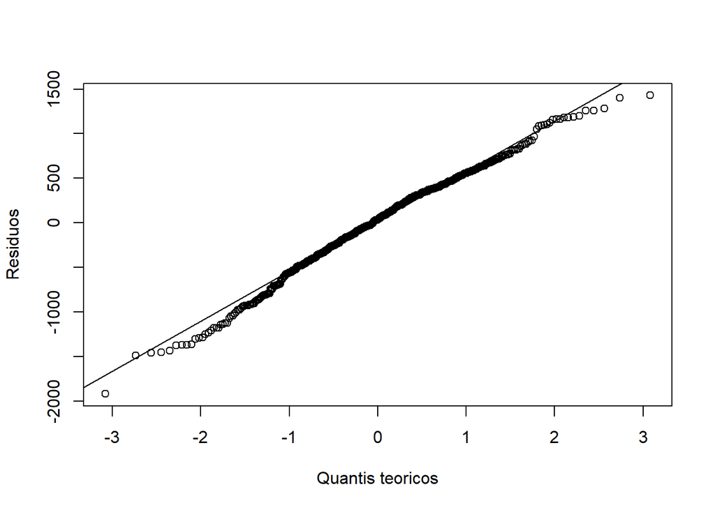

```
##
##  Shapiro-Wilk normality test
##
## data:  residuals(modelo4_stepwise)
## W = 0.9909, p-value = 0.004471
```

### Análise dos outliers do segundo modelo

### Rodar o terceiro modelo

```
##
## Call:
## lm(formula = cnt ~ ., data = TrainSet_2)
##
## Residuals:
##      Min       1Q   Median       3Q      Max
## -1246.38  -344.70    14.29   332.97  1189.14
##
## Coefficients: (1 not defined because of singularities)
##              Estimate Std. Error t value             Pr(>|t|)
## (Intercept)   1072.17     192.51   5.570    0.000000045375717 ***
## yr1           2203.76      48.40  45.530 < 0.0000000000000002 ***
## holiday1      -366.30     213.27  -1.718             0.086603 .
## workingday1    400.79      90.88   4.410    0.000013118772727 ***
## temp         -2238.22    1902.24  -1.177             0.240004
## atemp         7474.13    2054.91   3.637             0.000309 ***
## hum          -1346.31     233.35  -5.769    0.000000015336002 ***
## windspeed    -2215.29     347.70  -6.371    0.000000000487987 ***
## season21       605.07     137.18   4.411    0.000013069629662 ***
## season31       715.83     175.58   4.077    0.000054495101229 ***
## season41      1281.78     167.39   7.658    0.000000000000129 ***
## weekday11     -262.47      89.53  -2.931             0.003556 **
## weekday21     -176.19      87.78  -2.007             0.045368 *
## weekday31     -155.64      89.74  -1.734             0.083576 .
## weekday41      -64.58      85.52  -0.755             0.450557
## weekday51          NA         NA      NA                   NA
## weekday61      342.88      91.31   3.755             0.000197 ***
## weathersit21  -459.69      61.96  -7.419    0.000000000000649 ***
## weathersit31 -1860.18     168.47 -11.041 < 0.0000000000000002 ***
## mnth21          99.89     114.09   0.875             0.381806
## mnth31         457.86     127.76   3.584             0.000378 ***
## mnth41         658.28     199.17   3.305             0.001030 **
## mnth51        1140.23     213.91   5.330    0.000000159468835 ***
## mnth61         981.73     226.86   4.327    0.000018831457404 ***
## mnth71         297.49     265.72   1.120             0.263533
## mnth81         703.87     253.65   2.775             0.005765 **
## mnth91        1122.97     224.21   5.008    0.000000805837219 ***
## mnth101        996.76     218.73   4.557    0.000006792043908 ***
## mnth111        342.04     206.32   1.658             0.098093 .
## mnth121        248.67     175.35   1.418             0.156889
## ---
## Signif. codes:  0 '***' 0.001 '**' 0.01 '*' 0.05 '.' 0.1 ' ' 1
##
## Residual standard error: 493.4 on 425 degrees of freedom
## Multiple R-squared:  0.9374, Adjusted R-squared:  0.9332
## F-statistic: 227.1 on 28 and 425 DF,  p-value: < 0.00000000000000022
```

```
## Start:  AIC=5658.89
## cnt ~ yr + holiday + workingday + temp + atemp + hum + windspeed +
##     season2 + season3 + season4 + weekday1 + weekday2 + weekday3 +
##     weekday4 + weekday5 + weekday6 + weathersit2 + weathersit3 +
##     mnth2 + mnth3 + mnth4 + mnth5 + mnth6 + mnth7 + mnth8 + mnth9 +
##     mnth10 + mnth11 + mnth12
##
##
## Step:  AIC=5658.89
## cnt ~ yr + holiday + workingday + temp + atemp + hum + windspeed +
##     season2 + season3 + season4 + weekday1 + weekday2 + weekday3 +
##     weekday4 + weekday6 + weathersit2 + weathersit3 + mnth2 +
##     mnth3 + mnth4 + mnth5 + mnth6 + mnth7 + mnth8 + mnth9 + mnth10 +
##     mnth11 + mnth12
##
##               Df Sum of Sq       RSS    AIC
## - weekday4     1    138856 103616575 5657.5
## - mnth2        1    186617 103664337 5657.7
## - mnth7        1    305178 103782898 5658.2
## - temp         1    337081 103814801 5658.4
## <none>                     103477719 5658.9
## - mnth12       1    489647 103967367 5659.0
## - mnth11       1    669160 104146879 5659.8
## - holiday      1    718271 104195990 5660.0
## - weekday3     1    732395 104210115 5660.1
## - weekday2     1    980865 104458584 5661.2
## - mnth8        1   1874818 105352537 5665.0
## - weekday1     1   2092349 105570069 5666.0
## - mnth4        1   2659597 106137316 5668.4
## - mnth3        1   3127035 106604754 5670.4
## - atemp        1   3221039 106698758 5670.8
## - weekday6     1   3433547 106911266 5671.7
## - season3      1   4046789 107524508 5674.3
## - mnth6        1   4559414 108037133 5676.5
## - workingday   1   4734958 108212677 5677.2
## - season2      1   4736783 108214502 5677.2
## - mnth10       1   5056058 108533777 5678.6
## - mnth9        1   6107561 109585280 5682.9
## - mnth5        1   6917807 110395527 5686.3
## - hum          1   8104609 111582329 5691.1
```

[output cut: 219 more lines]

```
## - weekday6     1   3710111 108462675 5666.3
## - workingday   1   5495756 110248320 5673.7
## - season2      1   6950617 111703181 5679.6
## - mnth6        1   7651509 112404073 5682.5
## - hum          1   8186953 112939517 5684.6
## - mnth5        1   9120285 113872849 5688.4
## - mnth10       1   9502289 114254853 5689.9
## - season3      1   9975892 114728455 5691.8
## - windspeed    1  11849484 116602047 5699.1
## - weathersit2  1  13715347 118467911 5706.3
## - mnth9        1  15653936 120406499 5713.7
## - weathersit3  1  30548926 135301490 5766.6
## - season4      1  76007526 180760090 5898.1
## - atemp        1  78726990 183479554 5904.9
## - yr           1 506413572 611166136 6451.2
```

```
##
## Call:
## lm(formula = cnt ~ yr + holiday + workingday + atemp + hum +
##     windspeed + season2 + season3 + season4 + weekday1 + weekday2 +
##     weekday3 + weekday6 + weathersit2 + weathersit3 + mnth3 +
##     mnth4 + mnth5 + mnth6 + mnth8 + mnth9 + mnth10, data = TrainSet_2)
##
## Residuals:
##      Min       1Q   Median       3Q      Max
## -1227.56  -335.69    13.94   362.93  1182.64
##
## Coefficients:
##              Estimate Std. Error t value             Pr(>|t|)
## (Intercept)   1160.39     181.07   6.409  0.00000000038556910 ***
## yr1           2194.95      48.09  45.647 < 0.0000000000000002 ***
## holiday1      -419.62     204.50  -2.052             0.040781 *
## workingday1    370.09      77.83   4.755  0.00000270751426471 ***
## atemp         5228.38     290.50  17.998 < 0.0000000000000002 ***
## hum          -1324.62     228.23  -5.804  0.00000001257460913 ***
## windspeed    -2316.50     331.76  -6.982  0.00000000001103571 ***
## season21       660.67     123.54   5.348  0.00000014482480077 ***
## season31       818.45     127.75   6.407  0.00000000039012157 ***
## season41      1492.32      84.39  17.684 < 0.0000000000000002 ***
## weekday11     -227.51      76.62  -2.970             0.003149 **
## weekday21     -144.03      74.58  -1.931             0.054116 .
## weekday31     -120.05      76.91  -1.561             0.119279
## weekday61      355.02      90.87   3.907             0.000108 ***
## weathersit21  -461.74      61.47  -7.512  0.00000000000033871 ***
## weathersit31 -1876.76     167.40 -11.211 < 0.0000000000000002 ***
## mnth31         349.40      94.39   3.702             0.000242 ***
## mnth41         496.24     150.23   3.303             0.001035 **
## mnth51         940.23     153.49   6.126  0.00000000203585029 ***
## mnth61         741.49     132.15   5.611  0.00000003606869204 ***
## mnth81         406.06     111.86   3.630             0.000317 ***
## mnth91         837.47     104.35   8.025  0.00000000000000969 ***
## mnth101        676.04     108.12   6.253  0.00000000097171187 ***
## ---
## Signif. codes:  0 '***' 0.001 '**' 0.01 '*' 0.05 '.' 0.1 ' ' 1
##
## Residual standard error: 493 on 431 degrees of freedom
## Multiple R-squared:  0.9366, Adjusted R-squared:  0.9333
## F-statistic: 289.3 on 22 and 431 DF,  p-value: < 0.00000000000000022
```

```
## [1] 480.3462
```

### Análise dos resíduos do terceiro modelo

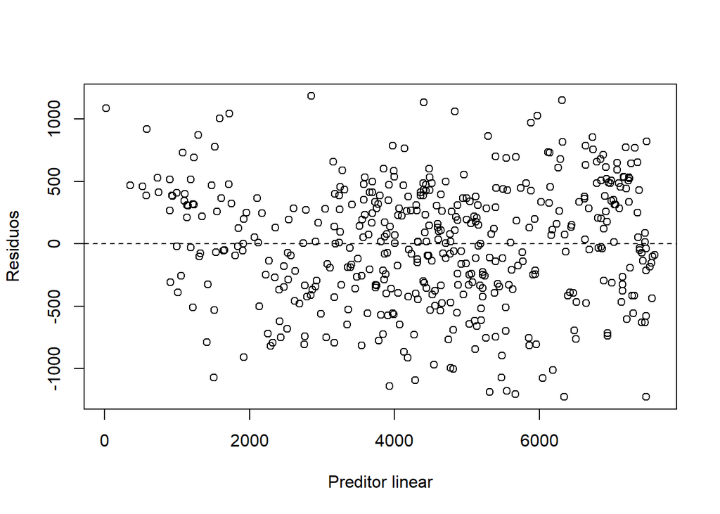

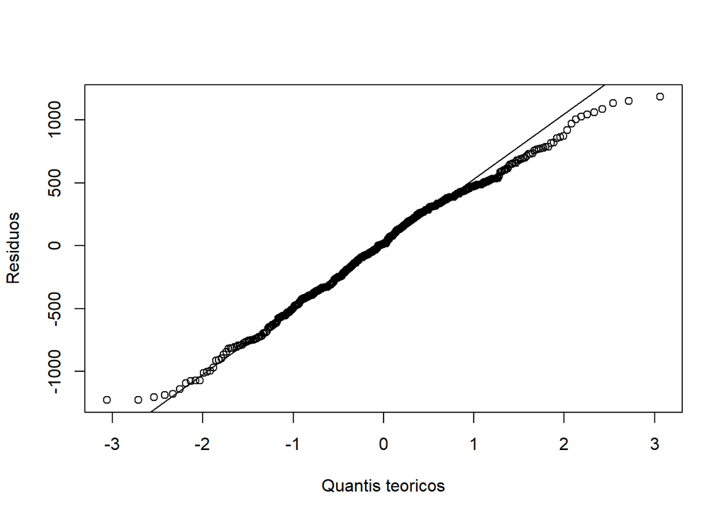

```
##
##  Shapiro-Wilk normality test
##
## data:  residuals(modelo5_stepwise)
## W = 0.99152, p-value = 0.01071
```

##————————————————————————————— ## AMOSTRA DE VALIDACAO ##—————————————————————————————

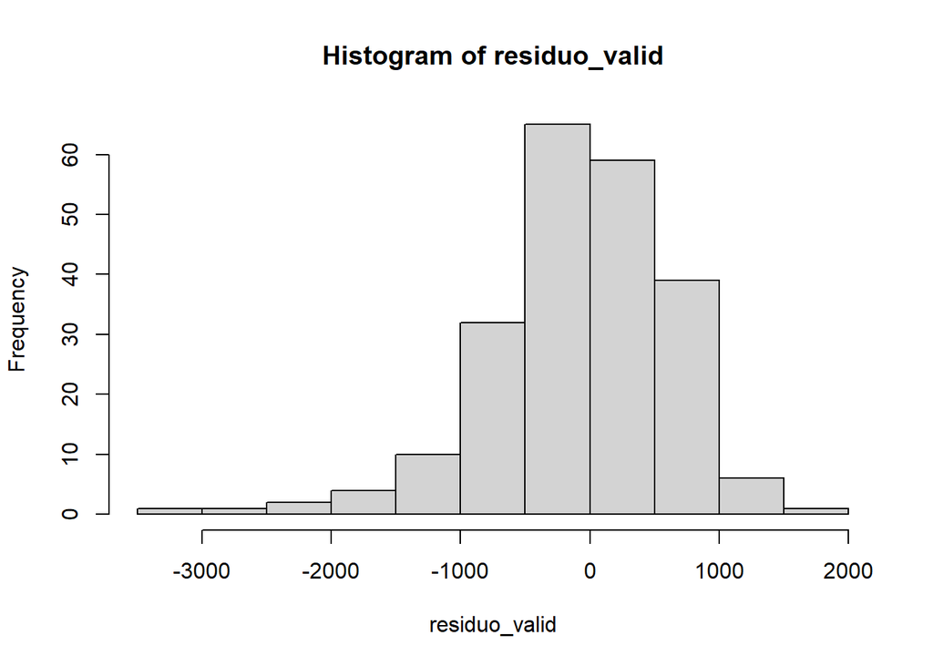

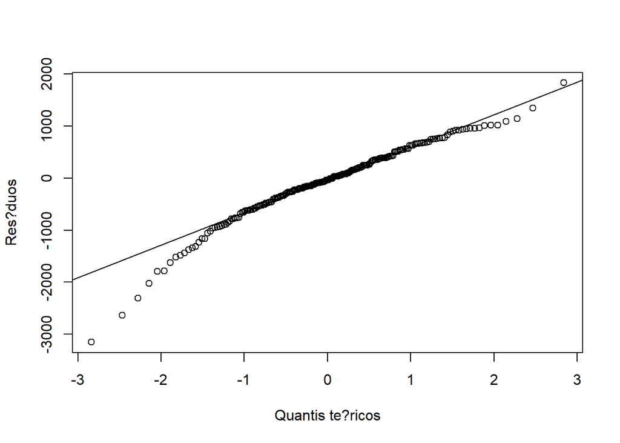

```
## [1] 706.6155
```